# P-Value 3 multi-variate linear

Nate Breznau

9/24/2021

### P-Value 3. Linear Associations, Adjusting for Other Variables

Now lets look at linear associations after adjusting for other variables that might explain the *income-happiness association*. For example, maybe people who are higher educated are happier, or people who have strong religious beliefs.

As with the last example (02_pvalue_linear.Rmd) we again generate a more continuous measure of happiness by combining the two questions on happiness and life satisfaction to form a scale, and by using the 8-category income measure as a closer approximation of continuous income.

```r
# load data
wvs_pvalue <- read_rds(here::here("data","wvs_pvalue.rds"))

wvs_pvalue <- wvs_pvalue %>%
  mutate(happy = ifelse(happiness > 0, happiness, NA), # remove missing
         happy = car::recode(happy, "1=4;2=3;3=2;4=1"),
         life_sati = ifelse(life_sat > 0, life_sat, NA),
         happyZ = scale(happy),
         life_satiZ = scale(life_sati),
         income8f = ifelse(income8 > 0, income8, NA),
         educ_isced11f = ifelse(educ_isced11 >= 0 & educ_isced11 < 9, educ_isced11, NA), # 9 = other
         god_importancef = ifelse(god_importance > 0, god_importance, NA)) %>%
  rowwise() %>%
  mutate(subj_well_being = mean(c(happyZ,life_satiZ), na.rm = T)) %>%
  subset(!is.na(income8f) & !is.na(happy) & !is.na(life_sati) & !is.na(educ_isced11f) & !is.na(god_importancef)) %>%
  ungroup()
```

Multivariate regression is one of the most common quantitative methods used to study social science phenomenon. It comes in many forms, but a basic application is to take a linear association like the one below.

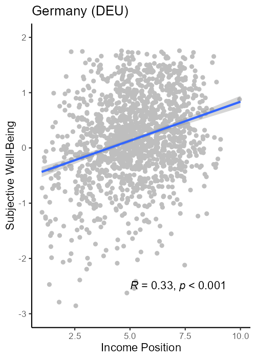

```r
knitr::include_graphics(here::here("results", "linear_p", "DEU_linear.png"))
```

But then adjust the values of subjective well-being for an association with education (or other variables). First lets simply look at the education and well-being linear association. Note that ISCED is not intended as a linear measure, but we will use it that way for now just for the purposes of example (and we removed 9 for ‘other’).

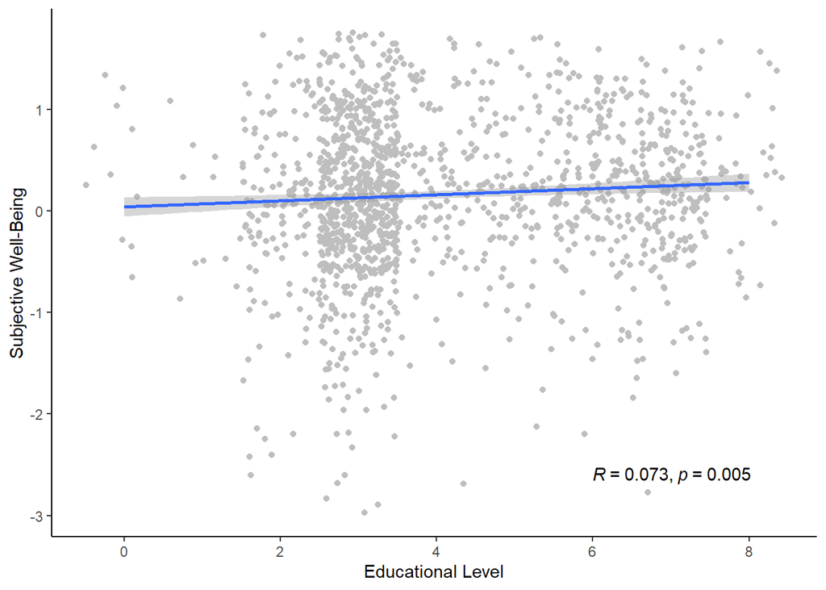

```r
set.seed(90210)
jitter <- position_jitter(width = 0.5, height = 0.5)

wvs_pvalue %>%
  subset(iso3c == "DEU") %>%
  ggplot(aes(x = educ_isced11f, y = subj_well_being)) +
  geom_point(color = "grey", position = jitter) +
  geom_smooth(method = "lm") +
  stat_cor(p.accuracy = 0.001, label.y = -2.6, label.x = 6) +
  labs(x = "Educational Level", y = "Subjective Well-Being") +
  theme_classic()
```

Let’s also look at the association of believing that god is important and SWB.

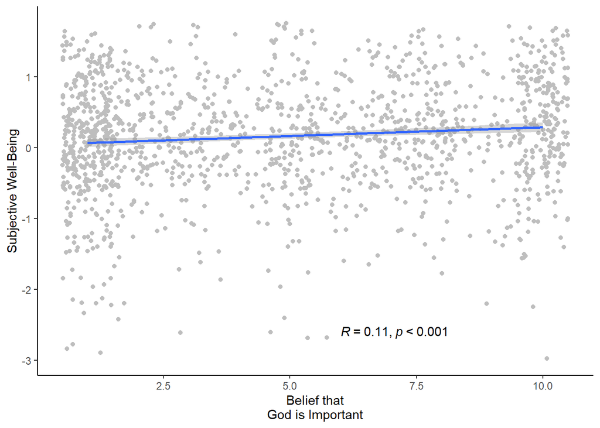

```r
set.seed(90210)
jitter <- position_jitter(width = 0.5, height = 0.5)

wvs_pvalue %>%
  subset(iso3c == "DEU") %>%
  ggplot(aes(x = god_importancef, y = subj_well_being)) +
  geom_point(color = "grey", position = jitter) +
  geom_smooth(method = "lm") +
  stat_cor(p.accuracy = 0.001, label.y = -2.6, label.x = 6) +
  labs(x = "Belief that\nGod is Important", y = "Subjective Well-Being") +
  theme_classic()
```

The association is not as strong as with income and subjective well-being. Nonetheless, we first adjust for the education association. There are two basic ways to do this. The first is to create a partial correlation.

Partial correlation

This involves ‘removing’ the variance in subjective well-being that is explained by education (their common variance) or belief in the importance of god, and the same for income.

This procedure:

1. Compute residuals for x (dependent) ~ z (independent) model
2. Compute residuals for y (dependent) ~ z (independent) model
3. Compute correlation between the residuals

rxy_z = cor(lm(X ~ Z)$residuals), lm(Y ~ Z)$residuals))

```r
# first predict subjective well-being, we will simply do it for each country
mod1 <- lm(subj_well_being ~ educ_isced11f*iso3c + iso3c + educ_isced11f, data = wvs_pvalue)
mod2 <- lm(subj_well_being ~ god_importancef*iso3c + iso3c + god_importancef, data = wvs_pvalue)
# same for income
mod3 <- lm(income8f ~ educ_isced11f*iso3c + iso3c + educ_isced11f, data = wvs_pvalue)
mod4 <- lm(income8f ~ god_importancef*iso3c + iso3c + god_importancef, data = wvs_pvalue)

# now predict values (calculate residuals)
wvs_pvalue$subj_i <- predict(mod1, newdata = wvs_pvalue)
wvs_pvalue$subj_i2 <- predict(mod2, newdata = wvs_pvalue)
wvs_pvalue$subj_i3 <- predict(mod3, newdata = wvs_pvalue)
wvs_pvalue$subj_i4 <- predict(mod4, newdata = wvs_pvalue)

wvs_pvalue$subj_partial_ed <- wvs_pvalue$subj_well_being - wvs_pvalue$subj_i
wvs_pvalue$subj_partial_god <- wvs_pvalue$subj_well_being - wvs_pvalue$subj_i2
wvs_pvalue$income_partial_ed <- wvs_pvalue$income8f - wvs_pvalue$subj_i3
wvs_pvalue$income_partial_god <- wvs_pvalue$income8f - wvs_pvalue$subj_i4
```

Partial Correlation of Income and SWB (adjusting for Education)

The result is the association of income and SWB that cannot be explained by the association of education and SWB.

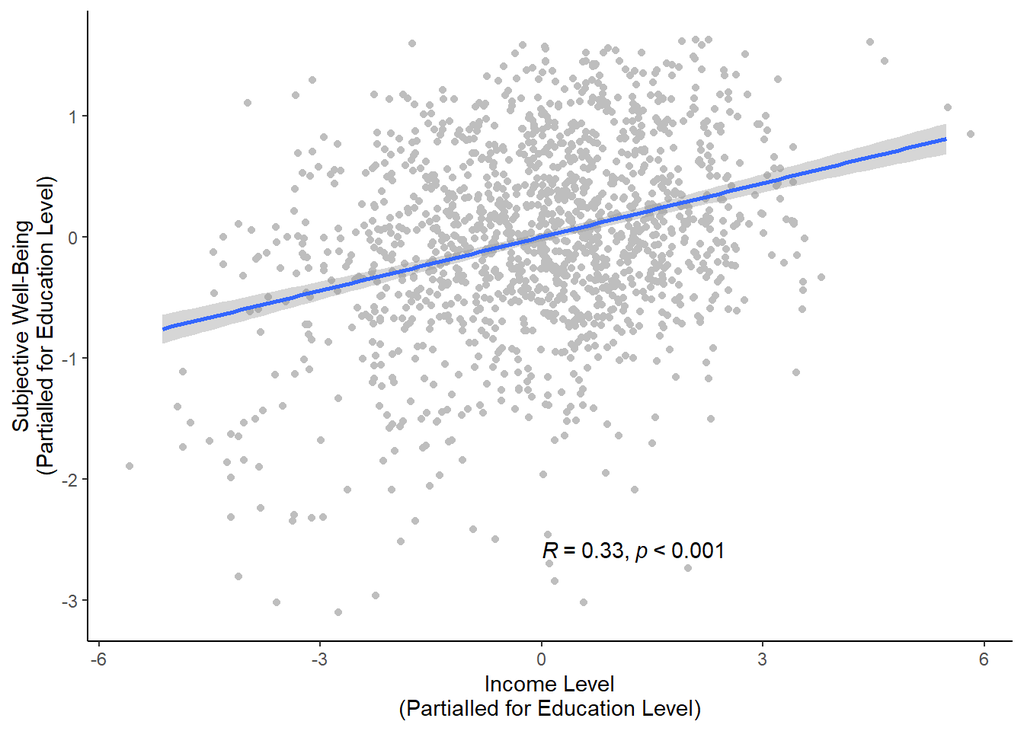

```r
set.seed(90210)
jitter <- position_jitter(width = 0.5, height = 0.5)

wvs_pvalue %>%
  subset(iso3c == "DEU") %>%
  ggplot(aes(x = income_partial_ed, y = subj_partial_ed)) +
  geom_point(color = "grey", position = jitter) +
  geom_smooth(method = "lm") +
  stat_cor(p.accuracy = 0.001, label.y = -2.6, label.x = 0) +
  labs(x = "Income Level\n(Partialled for Education Level)", y = "Subjective Well-Being\n(Partialled for Education Level)") +
  theme_classic()
```

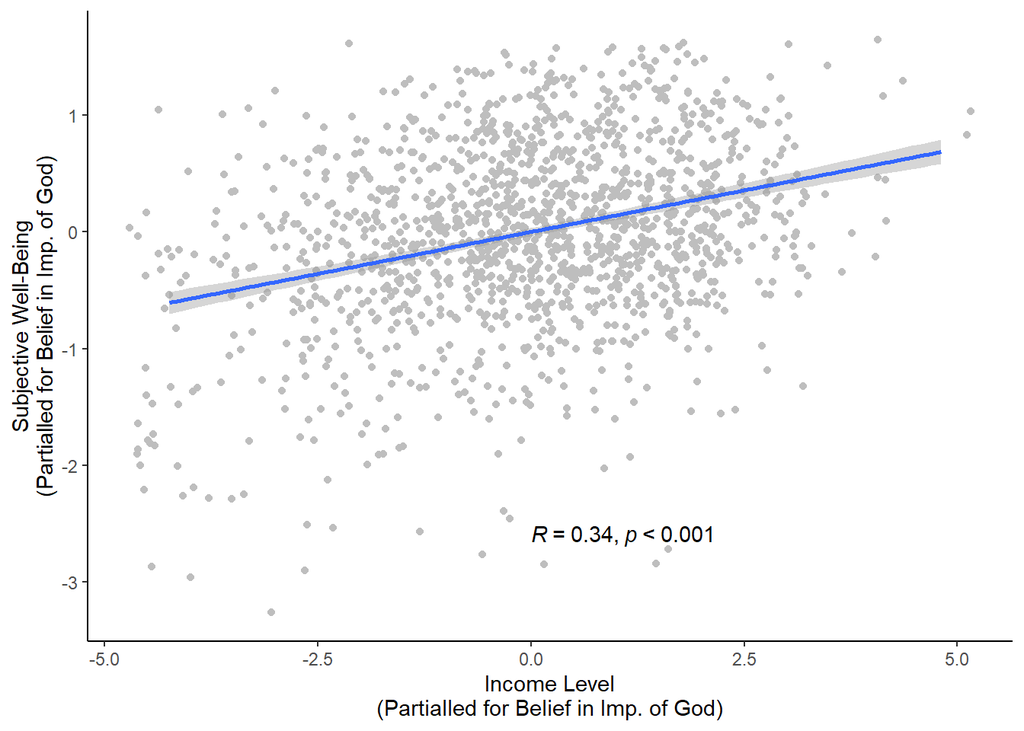

```r
set.seed(90210)
jitter <- position_jitter(width = 0.5, height = 0.5)

wvs_pvalue %>%
  subset(iso3c == "DEU") %>%
  ggplot(aes(x = income_partial_god, y = subj_partial_god)) +
  geom_point(color = "grey", position = jitter) +
  geom_smooth(method = "lm") +
  stat_cor(p.accuracy = 0.001, label.y = -2.6, label.x = 0) +
  labs(x = "Income Level\n(Partialled for Belief in Imp. of God)", y = "Subjective Well-Being\n(Partialled for Belief in Imp. of God)") +
  theme_classic()
```

Plot for all countries

NOTE: Not yet finised

```r
set.seed(90210)
jitter <- position_jitter(width = 0.5, height = 0.5)


#for (c in unique(wvs_pvalue$iso3c)) {
#  wvs_pvalue_temp <- wvs_pvalue %>%
#    subset(iso3c == c)
```

The other option is to run a regression. The advantage is that a regression can adjust for many variables at once.

Here are three regressions showing the linear association of income and SWB. 1. Just income and SWB 2. Income and SWB adjusting for education 3. Income and SWB adjusting for education and belief in importance of god

Start with Germany

```r
m1 <- lm(subj_well_being ~ income8f, data = subset(wvs_pvalue, iso3c == "DEU"))
m2 <- lm(subj_well_being ~ income8f + educ_isced11f, data = subset(wvs_pvalue, iso3c == "DEU"))
m3 <- lm(subj_well_being ~ income8f + educ_isced11f + god_importancef, data = subset(wvs_pvalue, iso3c == "DEU"))

export_summs(m1, m2, m3, coefs = c(
  "Income" = "income8f",
  "Education" = "educ_isced11f",
  "God Importance" = "god_importancef"
))
```

|  | Model 1 | Model 2 | Model 3 |
| --- | --- | --- | --- |
| Income | 0.14 *** | 0.15 *** | 0.15 *** |
|  | (0.01) | (0.01) | (0.01) |
| Education |  | -0.02 | -0.02 |
|  |  | (0.01) | (0.01) |
| God Importance |  |  | 0.03 *** |
|  |  |  | (0.01) |
| N | 1445 | 1445 | 1445 |
| R2 | 0.11 | 0.11 | 0.13 |
| *** p < 0.001; ** p < 0.01; * p < 0.05. |  |  |  |

Now Ethiopia

```r
m1 <- lm(subj_well_being ~ income8f, data = subset(wvs_pvalue, iso3c == "ETH"))
m2 <- lm(subj_well_being ~ income8f + educ_isced11f, data = subset(wvs_pvalue, iso3c == "ETH"))
m3 <- lm(subj_well_being ~ income8f + educ_isced11f + god_importancef, data = subset(wvs_pvalue, iso3c == "ETH"))

export_summs(m1, m2, m3, coefs = c(
  "Income" = "income8f",
  "Education" = "educ_isced11f",
  "God Importance" = "god_importancef"
))
```

|  | Model 1 | Model 2 | Model 3 |
| --- | --- | --- | --- |
| Income | 0.05 *** | 0.05 *** | 0.05 *** |
|  | (0.01) | (0.01) | (0.01) |
| Education |  | -0.02 | -0.02 |
|  |  | (0.01) | (0.01) |
| God Importance |  |  | 0.01 |
|  |  |  | (0.03) |
| N | 1222 | 1222 | 1222 |
| R2 | 0.01 | 0.02 | 0.02 |
| *** p < 0.001; ** p < 0.01; * p < 0.05. |  |  |  |

Now Vietnam

What do we see here?

```r
m1 <- lm(subj_well_being ~ income8f, data = subset(wvs_pvalue, iso3c == "VNM"))
m2 <- lm(subj_well_being ~ income8f + educ_isced11f, data = subset(wvs_pvalue, iso3c == "VNM"))
m3 <- lm(subj_well_being ~ income8f + educ_isced11f + god_importancef, data = subset(wvs_pvalue, iso3c == "VNM"))

export_summs(m1, m2, m3, coefs = c(
  "Income" = "income8f",
  "Education" = "educ_isced11f",
  "God Importance" = "god_importancef"
))
```

|  | Model 1 | Model 2 | Model 3 |
| --- | --- | --- | --- |
| Income | 0.06 *** | 0.07 *** | 0.07 *** |
|  | (0.01) | (0.01) | (0.01) |
| Education |  | -0.06 *** | -0.06 *** |
|  |  | (0.01) | (0.01) |
| God Importance |  |  | 0.01 |
|  |  |  | (0.01) |
| N | 1200 | 1200 | 1200 |
| R2 | 0.02 | 0.04 | 0.04 |
| *** p < 0.001; ** p < 0.01; * p < 0.05. |  |  |  |